# Homework 10

Solutions for Questions 1 and 2 will be available after Monday, November 2, 2026. No solution will be provided for Question 3.

Use the RLT package for Questions 1 and 2: `RLT` in R or `rlt` in Python. The node-size parameter is `nmin` in R and `min_samples_leaf` in Python; both stop splitting a node when it contains at most that many observations. The candidate-predictor parameter is `mtry` in both languages. Use ordinary random forests, with reinforcement turned off.

## Question 1: Bias-variance trade-off simulation

Two important tuning parameters of random forests are node size and `mtry`. We have performed some preliminary analysis in class. The goal of this question is to perform a larger simulation study for these two tuning parameters.

Consider a regression model with five jointly normally distributed predictors. Each predictor has mean 0 and variance 1, and the correlation between any two different predictors is 0.3. The response is

$$Y=X_1+X_3+X_5+\varepsilon,
\qquad \varepsilon\sim N(0,1),$$

where the noise is independent of the predictors. Thus the true regression function is $f(\mathbf{x})=x_1+x_3+x_5$.

1. Set up a simulation study with 100 repetitions. Generate 200 test predictor vectors once and keep them fixed. In each repetition, generate 200 new training observations and use the same training data for all tuning settings. Fit 500-tree forests, drawing 200 observations with replacement for each tree. Make the following two comparisons:
   - Fix `mtry` at 3 and vary node size over $1,5,10,20,30$.
   - Fix node size at 10 and vary `mtry` over $1,2,3,4,5$.

   Leave all other fitting parameters at their defaults. Record the predictions at each test point across repetitions. For each setting, estimate the squared bias and variance at each test point, then average them over the 200 test points. Compare predictions with $f(\mathbf{x})$ when estimating bias. Produce two figures, one for each tuning parameter, showing the averaged squared bias and variance. Set a random seed and report it.
2. Discuss your results in terms of the bias-variance trade-off:
   - How does a large node size, such as 30, affect the fit in this example?
   - What are the benefits and drawbacks of using a large `mtry` value?
   - If each tree instead sampled 100 observations with replacement, would you expect the preferred node size to shift toward smaller or larger values? Explain your reasoning. You may use an additional simulation to help, but a particular pattern is not guaranteed.

### Answer

I use seed `43210`. All forests use 500 trees with `resample.prob = 1` and `replacement = TRUE`, so each tree draws 200 observations with replacement, and `reinforcement = FALSE`. Every other RLT parameter is left at its default, including `split.gen = "random"` with `nsplit = 1`.

**(a) The simulation.**

```r
library(RLT)
set.seed(43210)

p <- 5; n <- 200; ntest <- 200; nrep <- 100
Sigma <- matrix(0.3, p, p); diag(Sigma) <- 1; L <- chol(Sigma)
gen_X   <- function(m) matrix(rnorm(m * p), m, p) %*% L
f_true  <- function(X) X[, 1] + X[, 3] + X[, 5]

Xtest <- gen_X(ntest)                      # generated once and held fixed
ftest <- f_true(Xtest)

settings <- rbind(data.frame(varying = "nmin", mtry = 3,   nmin = c(1, 5, 10, 20, 30)),
                  data.frame(varying = "mtry", mtry = 1:5, nmin = 10))
uniq <- settings[!duplicated(paste(settings$mtry, settings$nmin)), ]   # mtry=3,nmin=10 is shared

preds <- array(NA_real_, c(nrep, ntest, nrow(uniq)))
for (r in 1:nrep) {
  Xtr <- gen_X(n); ytr <- f_true(Xtr) + rnorm(n)        # one training set shared by all settings
  for (j in seq_len(nrow(uniq))) {
    fit <- RLT(x = Xtr, y = ytr, model = "regression", ntrees = 500,
               mtry = uniq$mtry[j], nmin = uniq$nmin[j],
               resample.prob = 1, replacement = TRUE, importance = FALSE)
    preds[r, , j] <- predict(fit, Xtest)$Prediction
  }
}
```

[output not shown]

[output cut: 845 more lines]

[output not shown]

```r
# at each test point: squared bias against f(x), and variance across the 100 repetitions
stats <- t(sapply(seq_len(nrow(uniq)), function(j) {
  m <- colMeans(preds[, , j])
  c(bias2 = mean((m - ftest)^2),
    variance = mean(apply(preds[, , j], 2, function(z) mean((z - mean(z))^2))))
}))
uniq <- cbind(uniq, stats); uniq$mse <- uniq$bias2 + uniq$variance
key  <- paste(uniq$mtry, uniq$nmin)
by_nmin <- uniq[match(paste(3, c(1, 5, 10, 20, 30)), key), ]
by_mtry <- uniq[match(paste(1:5, 10), key), ]
knitr::kable(rbind(by_nmin, by_mtry)[, c("varying", "mtry", "nmin", "bias2", "variance", "mse")],
             digits = 4, row.names = FALSE,
             col.names = c("Varying", "mtry", "nmin", "Squared bias", "Variance", "Sum"),
             caption = "Averaged over the 200 fixed test points, across 100 repetitions.")
```

Averaged over the 200 fixed test points, across 100 repetitions.

| Varying | mtry | nmin | Squared bias | Variance | Sum |
| --- | --- | --- | --- | --- | --- |
| nmin | 3 | 1 | 0.3572 | 0.1156 | 0.4728 |
| nmin | 3 | 5 | 0.3594 | 0.1029 | 0.4624 |
| nmin | 3 | 10 | 0.3962 | 0.0846 | 0.4807 |
| nmin | 3 | 20 | 0.5215 | 0.0686 | 0.5902 |
| nmin | 3 | 30 | 0.6623 | 0.0627 | 0.7249 |
| mtry | 1 | 10 | 1.0864 | 0.0460 | 1.1324 |
| mtry | 2 | 10 | 0.5382 | 0.0671 | 0.6052 |
| nmin | 3 | 10 | 0.3962 | 0.0846 | 0.4807 |
| mtry | 4 | 10 | 0.3407 | 0.1012 | 0.4419 |
| mtry | 5 | 10 | 0.3108 | 0.1155 | 0.4263 |

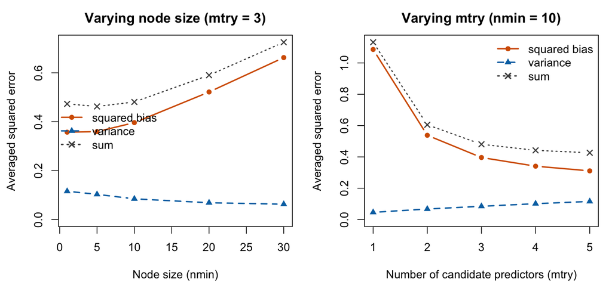

```r
ok <- c("#D55E00", "#0072B2", "grey30")
par(mfrow = c(1, 2), mar = c(4.3, 4.3, 2.6, 1))

plot(by_nmin$nmin, by_nmin$bias2, type = "b", pch = 16, lwd = 2, col = ok[1],
     ylim = range(0, by_nmin$bias2, by_nmin$mse),
     xlab = "Node size (nmin)", ylab = "Averaged squared error",
     main = "Varying node size (mtry = 3)")
lines(by_nmin$nmin, by_nmin$variance, type = "b", pch = 17, lwd = 2, lty = 2, col = ok[2])
lines(by_nmin$nmin, by_nmin$mse, type = "b", pch = 4, lwd = 1.6, lty = 3, col = ok[3])
legend("left", bty = "n", lwd = 2, pch = c(16, 17, 4), lty = c(1, 2, 3), col = ok,
       legend = c("squared bias", "variance", "sum"))

plot(by_mtry$mtry, by_mtry$bias2, type = "b", pch = 16, lwd = 2, col = ok[1],
     ylim = range(0, by_mtry$bias2, by_mtry$mse),
     xlab = "Number of candidate predictors (mtry)", ylab = "Averaged squared error",
     main = "Varying mtry (nmin = 10)")
lines(by_mtry$mtry, by_mtry$variance, type = "b", pch = 17, lwd = 2, lty = 2, col = ok[2])
lines(by_mtry$mtry, by_mtry$mse, type = "b", pch = 4, lwd = 1.6, lty = 3, col = ok[3])
legend("topright", bty = "n", lwd = 2, pch = c(16, 17, 4), lty = c(1, 2, 3), col = ok,
       legend = c("squared bias", "variance", "sum"))
```

**(b) Discussion.**

*A large node size such as 30.* Squared bias rises from 0.357 at `nmin = 1` to 0.662 at `nmin = 30`, while variance falls only from 0.116 to 0.063. The variance saving is about 0.053; the bias cost is about 0.305, roughly 6 times larger, so the sum is worst at `nmin = 30`.

The reason is that stopping at 30 observations out of 200 means each tree can split at most a few times before its nodes are too small to divide, so the fitted surface is a coarse step function with very few distinct levels. The true $f(\mathbf x)=x_1+x_3+x_5$ is smooth and unbounded, and a coarse piecewise-constant fit cannot track it at the edges of the predictor space, where the error is largest. Averaging 500 trees already controls variance effectively, so there is little variance left for a large node size to remove — the usual reason deep trees are safe inside a forest. The best node size here is 5, and `nmin = 1` is barely worse.

*Benefits and drawbacks of a large `mtry`.* Squared bias falls steeply from 1.086 at `mtry = 1` to 0.311 at `mtry = 5`, while variance rises from 0.046 to 0.116. The sum is minimized at `mtry = 5`, the largest value, which is bagging.

The benefit is that each split gets to consider the genuinely relevant predictors. Only $X_1, X_3, X_5$ enter the response, so with `mtry = 1` a split sees a useful variable with probability $3/5$ and otherwise must split on noise, which is why its squared bias is more than three times the best value. The drawback is correlation between trees: when every tree evaluates the same five candidates, they tend to choose the same splits, the ensemble members become similar, and averaging removes less variance — exactly the rise seen in the variance curve.

The balance depends on the signal density. Here three of five predictors matter and they are correlated at 0.3, so there is little to gain from forcing diversity and much to lose, and large `mtry` wins. In a sparse problem — a handful of relevant predictors among hundreds — a small `mtry` is usually better, because the decorrelation benefit is real and the chance of missing the signal at any one split is offset over many splits and trees.

*If each tree drew 100 observations instead of 200.* I would expect the preferred node size to shift toward **smaller** values, and a direct simulation supports that.

```r
set.seed(43210)
nmins <- c(1, 5, 10, 20, 30); probs <- c(1, 0.5)      # 200 vs 100 draws per tree
P2 <- array(NA_real_, c(nrep, ntest, length(nmins), length(probs)))
for (r in 1:nrep) {
  Xtr <- gen_X(n); ytr <- f_true(Xtr) + rnorm(n)
  for (a in seq_along(nmins)) for (b in seq_along(probs)) {
    P2[r, , a, b] <- predict(RLT(x = Xtr, y = ytr, model = "regression", ntrees = 500,
                                 mtry = 3, nmin = nmins[a], resample.prob = probs[b],
                                 replacement = TRUE, importance = FALSE), Xtest)$Prediction
  }
}
```

[output not shown]

[output cut: 945 more lines]

[output not shown]

```r
comp <- do.call(rbind, lapply(seq_along(probs), function(b) do.call(rbind, lapply(seq_along(nmins), function(a) {
  m <- colMeans(P2[, , a, b]); v <- mean(apply(P2[, , a, b], 2, function(z) mean((z - mean(z))^2)))
  data.frame(draws = 200 * probs[b], nmin = nmins[a], bias2 = mean((m - ftest)^2),
             variance = v, mse = mean((m - ftest)^2) + v)
}))))
knitr::kable(comp, digits = 4, row.names = FALSE, caption = "Node size at two resample sizes.")
```

Node size at two resample sizes.

| draws | nmin | bias2 | variance | mse |
| --- | --- | --- | --- | --- |
| 200 | 1 | 0.3699 | 0.1181 | 0.4880 |
| 200 | 5 | 0.3726 | 0.1040 | 0.4765 |
| 200 | 10 | 0.4101 | 0.0849 | 0.4950 |
| 200 | 20 | 0.5330 | 0.0672 | 0.6002 |
| 200 | 30 | 0.6731 | 0.0590 | 0.7321 |
| 100 | 1 | 0.5008 | 0.0878 | 0.5886 |
| 100 | 5 | 0.5115 | 0.0760 | 0.5875 |
| 100 | 10 | 0.5993 | 0.0622 | 0.6614 |
| 100 | 20 | 0.8574 | 0.0509 | 0.9082 |
| 100 | 30 | 1.1514 | 0.0453 | 1.1967 |

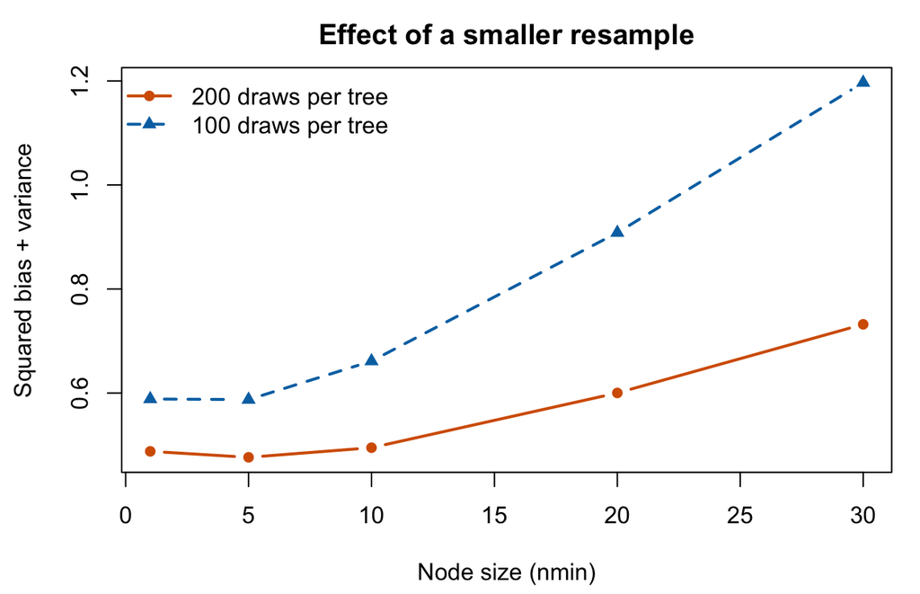

```r
d200 <- comp[comp$draws == 200, ]; d100 <- comp[comp$draws == 100, ]
par(mar = c(4.3, 4.3, 2.4, 1))
plot(d200$nmin, d200$mse, type = "b", pch = 16, lwd = 2, col = ok[1],
     ylim = range(comp$mse), xlab = "Node size (nmin)", ylab = "Squared bias + variance",
     main = "Effect of a smaller resample")
lines(d100$nmin, d100$mse, type = "b", pch = 17, lwd = 2, lty = 2, col = ok[2])
legend("topleft", bty = "n", lwd = 2, pch = c(16, 17), lty = c(1, 2), col = ok,
       legend = c("200 draws per tree", "100 draws per tree"))
```

The mechanism is that `nmin` is an absolute count, so its effect depends on how much data a tree has. A terminal node of 30 observations is 15% of a 200-observation sample but 30% of a 100-observation sample, so the same `nmin` forces a much coarser partition and the tree stops splitting sooner. The table shows this: at 100 draws the squared bias at `nmin = 30` is 1.151, against 0.673 at 200 draws, and the penalty for large node size steepens throughout.

The countervailing effect — each tree being noisier with less data, which would argue for more smoothing — is visible but small: variance at every node size is actually *lower* with 100 draws, because smaller resamples make the trees less similar to each other and averaging then removes more variance. With bias growing and variance shrinking, both forces point the same way.

The numbers themselves are a weaker statement than the mechanism. The minimum sits at `nmin = 5` for both resample sizes, but the margin changes: at 200 draws `nmin = 5` beats `nmin = 1` by 0.0115, whereas at 100 draws the two are within 0.0011 of each other. The optimum has flattened and moved toward 1 without crossing it on this grid, which is the shift in direction the reasoning predicts, at a magnitude too small for 100 repetitions to resolve confidently.

## Question 2: Tuning random forests for MNIST

Use `mnist-first2000.csv.gz` from the combined ZIP. It contains 2,000 MNIST observations, with the digit label `Digit` and 784 pixel values.

- From the first 1,000 observations, keep digits 1, 6, and 7 as the training data. From the remaining 1,000 observations, keep the same digits as the test data.
- Fit PCA to the training pixels, centering but not scaling them. Use the first 20 principal components as predictors, and project the test observations using the same training means and loadings.

Complete the following tasks using RLT classification forests with 1,000 trees. For each tree, draw a bootstrap sample of the same size as the training set.

1. Fit a random forest with the default `mtry` and node-size settings. Report the out-of-bag (OOB) misclassification rate.
2. Construct a grid of `mtry` and node-size values to tune the model. Select the setting using OOB misclassification rate. Report the OOB error for each setting and the selected values. Calculate and present the selected forest’s OOB permutation variable importance for the 20 principal components. Comment on your results.
3. Apply the selected model to the test data and report the misclassification rate and confusion matrix. Use the test labels only for this final assessment.

### Answer

```r
set.seed(43210)
mnist <- read.csv(gzfile("data/mnist-first2000.csv.gz"))
digits <- c(1, 6, 7)

train_raw <- mnist[1:1000, ][mnist$Digit[1:1000] %in% digits, ]
test_raw  <- mnist[1001:2000, ][mnist$Digit[1001:2000] %in% digits, ]
c(n_train = nrow(train_raw), n_test = nrow(test_raw))
```

```
n_train  n_test
    327     317
```

```r
rbind(train = table(train_raw$Digit), test = table(test_raw$Digit))
```

```
        1   6   7
train 116  94 117
test  104 106 107
```

```r
# PCA on the training pixels: centered, not scaled; test projected with training means and loadings
pix_train <- as.matrix(train_raw[, -1]); pix_test <- as.matrix(test_raw[, -1])
pca <- prcomp(pix_train, center = TRUE, scale. = FALSE)
Ztrain <- pca$x[, 1:20]
Ztest  <- scale(pix_test, center = pca$center, scale = FALSE) %*% pca$rotation[, 1:20]
ytrain <- as.factor(train_raw$Digit); ytest <- as.factor(test_raw$Digit)
c(variance_explained_by_20_PCs = round(sum(pca$sdev[1:20]^2) / sum(pca$sdev^2), 4))
```

```
variance_explained_by_20_PCs
                      0.7713
```

```r
# RLT returns per-tree class probabilities and a bootstrap count matrix, so the OOB
# prediction for observation i averages only the trees where it was out of bag.
oob_error <- function(fit, X, y) {
  per_tree <- predict(fit, X)$AllPrediction
  is_oob   <- fit$ObsTrack == 0
  total <- matrix(0, nrow(X), ncol(per_tree[[1]])); count <- numeric(nrow(X))
  for (t in seq_along(per_tree)) {
    k <- is_oob[, t]
    total[k, ] <- total[k, ] + per_tree[[t]][k, , drop = FALSE]
    count[k] <- count[k] + 1
  }
  used <- count > 0
  pred <- levels(y)[max.col(total[used, , drop = FALSE], ties.method = "first")]
  mean(pred != as.character(y)[used])
}
```

**(a) Default settings.**

```r
default_mtry <- max(1, as.integer(ncol(Ztrain) / 3))
default_nmin <- max(1, as.integer(log(nrow(Ztrain))))
c(default_mtry = default_mtry, default_nmin = default_nmin)
```

```
default_mtry default_nmin
           6            5
```

```r
rf_default <- RLT(x = Ztrain, y = ytrain, model = "classification", ntrees = 1000,
                  resample.prob = 1, replacement = TRUE, track.obs = TRUE, importance = FALSE)
```

```
Package is not compiled with OpenMP (omp.h).
```

```r
oob_default <- oob_error(rf_default, Ztrain, ytrain)
c(OOB_misclassification = round(oob_default, 4))
```

```
OOB_misclassification
               0.0306
```

With RLT’s defaults (`mtry = 6`, `nmin = 5`) the out-of-bag misclassification rate is **0.0306**, about 10 of the 327 training images.

**(b) Tuning by OOB error, and variable importance.**

```r
grid10 <- expand.grid(mtry = c(2, 4, 6, 10, 14, 20), nmin = c(1, 3, 5, 10, 20))
grid10$oob <- sapply(seq_len(nrow(grid10)), function(i) {
  oob_error(RLT(x = Ztrain, y = ytrain, model = "classification", ntrees = 1000,
                mtry = grid10$mtry[i], nmin = grid10$nmin[i], resample.prob = 1,
                replacement = TRUE, track.obs = TRUE, importance = FALSE), Ztrain, ytrain)
})
```

[output not shown]

```r
wide <- reshape(grid10, idvar = "mtry", timevar = "nmin", direction = "wide")
names(wide) <- c("mtry", paste0("nmin=", c(1, 3, 5, 10, 20)))
knitr::kable(wide, digits = 4, row.names = FALSE,
             caption = "OOB misclassification rate for all 30 settings.")
```

OOB misclassification rate for all 30 settings.

| mtry | nmin=1 | nmin=3 | nmin=5 | nmin=10 | nmin=20 |
| --- | --- | --- | --- | --- | --- |
| 2 | 0.0245 | 0.0153 | 0.0214 | 0.0214 | 0.0367 |
| 4 | 0.0214 | 0.0336 | 0.0306 | 0.0367 | 0.0336 |
| 6 | 0.0306 | 0.0336 | 0.0336 | 0.0245 | 0.0367 |
| 10 | 0.0336 | 0.0306 | 0.0336 | 0.0336 | 0.0459 |
| 14 | 0.0367 | 0.0336 | 0.0398 | 0.0398 | 0.0428 |
| 20 | 0.0336 | 0.0306 | 0.0398 | 0.0428 | 0.0459 |

```r
chosen <- grid10[which.min(grid10$oob), ]
c(selected_mtry = chosen$mtry, selected_nmin = chosen$nmin, OOB = round(chosen$oob, 4))
```

```
selected_mtry selected_nmin           OOB
       2.0000        3.0000        0.0153
```

```r
rf_best <- RLT(x = Ztrain, y = ytrain, model = "classification", ntrees = 1000,
               mtry = chosen$mtry, nmin = chosen$nmin, resample.prob = 1,
               replacement = TRUE, track.obs = TRUE, importance = TRUE)
```

```
Package is not compiled with OpenMP (omp.h).
```

```r
vi <- setNames(as.vector(rf_best$VarImp), paste0("PC", 1:20))
round(sort(vi, decreasing = TRUE), 4)
```

```
   PC2    PC1    PC3    PC5    PC6    PC7    PC4   PC11   PC12   PC10   PC13
0.4788 0.3344 0.1066 0.0944 0.0927 0.0719 0.0712 0.0659 0.0489 0.0474 0.0472
  PC18    PC8   PC16   PC14    PC9   PC17   PC20   PC19   PC15
0.0459 0.0409 0.0407 0.0396 0.0391 0.0353 0.0312 0.0272 0.0240
```

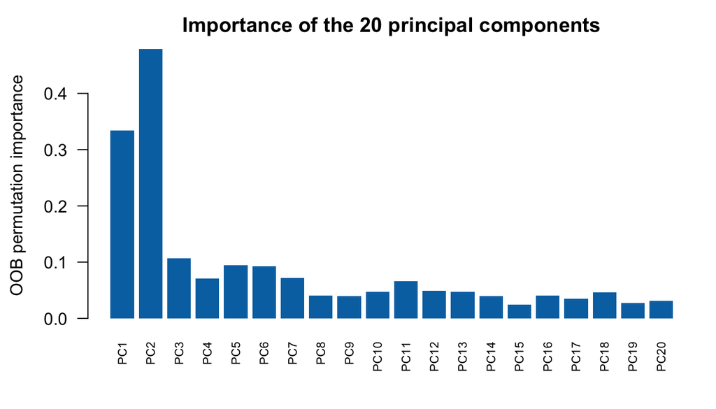

```r
par(mar = c(4.3, 4.3, 2.4, 1))
barplot(vi, las = 2, col = "#0072B2", border = NA, cex.names = 0.7,
        ylab = "OOB permutation importance",
        main = "Importance of the 20 principal components")
```

The grid of 30 settings spans OOB errors from 0.0153 to 0.0459. The selected setting is **`mtry = 2`, `nmin = 3`**, with OOB error 0.0153 — better than the default’s 0.0306, though by only 5 training images, which is well inside the noise of an OOB estimate on 327 observations. The broad pattern across the table is more trustworthy than the exact winner: small `mtry` does better than large, and node size matters little in comparison.

That `mtry = 2` beats `mtry = 20` is the decorrelation effect from Question 1 operating in the opposite regime. Here the signal is concentrated in a few components, so restricting each split to a couple of candidates forces different trees down different paths and the averaging gains more than the individual trees lose.

Importance is dominated by **PC2 (0.479) and PC1 (0.334)**, together far above the rest; PC3 follows at 0.107, and everything from roughly PC8 onward sits near 0.04. This is what one expects from PCA on three visually distinct digits: the leading components capture the gross ink-distribution contrasts that separate a thin vertical 1 from a looped 6 and a horizontal-topped 7, while later components encode handwriting variation shared across all three classes. Note that PCA maximizes variance without reference to the labels, so component order need not match class relevance — PC2 outranking PC1 here is a small instance of that.

**(c) Test performance.**

```r
pred_idx  <- predict(rf_best, Ztest)$Prediction        # 0-based class index
pred_test <- levels(ytrain)[pred_idx + 1]
test_error <- mean(pred_test != as.character(ytest))
c(test_misclassification = round(test_error, 4),
  n_errors = sum(pred_test != as.character(ytest)), n_test = length(ytest))
```

```
test_misclassification               n_errors                 n_test
                0.0126                 4.0000               317.0000
```

```r
table(Observed = ytest, Predicted = pred_test)
```

```
        Predicted
Observed   1   6   7
       1 102   0   2
       6   0 106   0
       7   1   1 105
```

The selected forest misclassifies **4 of 317** test images, a rate of **0.0126**. The test labels were not used at any earlier point: the grid was scored entirely by out-of-bag error on the training images.

The test error is close to the OOB estimate of 0.0153, which is the expected behaviour — out-of-bag error is computed from trees that never saw the observation, so it is a genuine held-out estimate rather than a training-set figure, and it is why no separate validation split was needed for tuning. The remaining errors are all 1-versus-7 confusions plus one 7 called a 6, which is the sensible failure mode: a 1 and a 7 differ mainly by the top stroke, and that distinction lives in finer detail than the first 20 principal components, which retain 77.1% of pixel variance, preserve well. Digit 6 is never once confused with a 1.

## Question 3: Planning a random-forest analysis skill

In earlier homework, some students wrote long skill files with detailed instructions, while others wrote short skills emphasizing their specific requirements or references. These approaches may perform differently depending on the AI and the task. A capable AI may already know standard ways to perform an analysis, so some instructions may be redundant, add little value, or sometimes make the analysis worse. It may be more useful to specify your personal choices for the analysis. An AI with more limited knowledge may benefit from detailed instructions that remind it of the steps to perform.

1. Write one paragraph describing how you would write a skill that directs an AI to perform a random-forest analysis and produce a report for a future dataset. Discuss how you would balance standard analysis instructions with your personal preferences, considering the AI’s capabilities.
2. Provide **10 instructions** you would consider including in the skill, **ordered from the most basic instructions to the more personal preferences**. Your list may cover computation, tuning, tables, figures, interpretation, presentation, or other aspects of a random-forest report.

You only need to discuss how the skill should be written. You are not required to write a complete skill file or test it.

### Answer

**(a) How I would write the skill.**

My two attempts so far point in one direction. My Homework 7 skill ran to 3,465 bytes of detailed procedure, and the peer review it received objected to its *consequences*, not its gaps: the parameter counts were wrong, 29 candidates could not fit in a one-page table, and the findings section ran past its own sentence limit. The Homework 9 skill was 43 lines, and the analysis it produced was cleaner. The reason, I think, is that a capable model already knows how to fit a random forest, tune `mtry` and node size, and build a confusion matrix; writing those steps out buys nothing and costs space, while every extra rule is another thing the model can violate under the page limit. What it does *not* reliably know is which of several defensible choices I want. So I would spend almost nothing on the mechanics of random forests and almost everything on the decisions where reasonable analysts differ: that out-of-bag error is the tuning criterion rather than a separate validation split, that importance means permutation importance rather than impurity decrease, that ties within one standard error resolve toward the simpler model, and that the test set is touched exactly once. I would also state the *budget* rather than the procedure — a maximum number of candidate settings, one figure, one table, one page — because the failure I actually observed was a report that obeyed every local instruction and still overflowed. Two further things I would do differently: give the agent one worked numerical check it must perform and report, since both of my skills produced numbers I had to verify by hand afterwards, and say explicitly what to do when the evidence is weak, because in both my Homework 7 and Homework 9 analyses every candidate landed within one standard error, and a skill that assumes a clear winner invites the agent to manufacture one. Finally, I would keep the skill dataset-independent and short enough to re-read in full before every use, since a skill I cannot check in a minute is a skill whose violations I will not notice.

**(b) Ten instructions, most basic first.**

1. Use only the dataset, response, and predictors supplied at invocation; never assume variable names or substitute a different dataset.
2. Report the random seed and every resampling choice, so the entire analysis can be reproduced exactly.
3. Reserve a stratified test set before any model fitting, and do not read its labels until the final evaluation.
4. Fit all preprocessing — imputation, encoding, centering, any embedding — inside each resample, never on the full data before tuning.
5. Tune `mtry` and node size together over a stated grid, and report the grid in full rather than only its winner.
6. Use out-of-bag error as the tuning criterion for forests, rather than a separate cross-validation loop, and say so in the report.
7. Report a standard error next to every error estimate, and never describe a difference smaller than that as real.
8. Use permutation importance computed out of bag, not impurity-decrease importance, and state that ranking is not causal.
9. When several settings fall within one standard error of the best, select the simplest — fewer candidate predictors, larger node size — and name the rule being applied.
10. Keep the report to one page with exactly one figure and one table, cap the candidate grid at what that table can show in full, state plainly when the evidence does not separate the candidates, and recompute one reported number by hand as a check.

The ordering runs from instructions almost any analyst would accept (1–4), through choices with defensible alternatives (5–7), to the ones that are genuinely mine (8–10). Items 9 and 10 are the two I would keep if I could keep only two, because they encode the lessons from both sides of the peer review: the simplicity rule prevents chasing noise, and the page-and-table budget is the constraint my earlier skill violated.